# Psyc 499: Text as Data

Introduction to Neural Networks

Joe Hoover

02.28.19 - Week 8 Lab

```r
library(tidyverse)
```

```r
if(require(knitr) == F) {
  install.packages('knitr')
  require('knitr')
}
```

```r
#
# if(require(kerasR) == F) {
#   install.packages('kerasR')
#   require('kerasR')
# }
```

## Introduction to the Perceptron

### Learning the AND function

First, let’s define our input matrix $\boldsymbol{X}_{ij}$, which contains $N$ observations for $J$ features $\forall i \in {1,...,N}$ where $N = 4$ and $\forall j \in {1,...,J}$ where $J = 2$.

```r
X <- as.matrix(tibble(x0 = c(1,1,1,1), x1 = c(0,0,1,1), x2 = c(0,1,0,1)))
as_tibble(X)
```

| x0 | x1 | x2 |
| --- | --- | --- |
| 1 | 0 | 0 |
| 1 | 0 | 1 |
| 1 | 1 | 0 |
| 1 | 1 | 1 |

```r
R <- as.matrix(tibble(r = c(0, 0, 0, 1)))
as_tibble(R)
```

| r |
| --- |
| 0 |
| 0 |
| 0 |
| 1 |

```r
W <- as.matrix(tibble(w0 = -1.5, w1 = 1, w2 = 1))
as_tibble(W)
```

| w0 | w1 | w2 |
| --- | --- | --- |
| -1.5 | 1 | 1 |

```r
cat(' Dimensions of X: ', dim(X), '\n', 'Dimensions of W: ', dim(W))
```

```
 Dimensions of X:  4 3
 Dimensions of W:  1 3
```

- What dimensions should our output matrix have?

```r
X %*% t(W)
```

```
     [,1]
[1,] -1.5
[2,] -0.5
[3,] -0.5
[4,]  0.5
```

```r
W %*% t(X)
```

```
     [,1] [,2] [,3] [,4]
[1,] -1.5 -0.5 -0.5  0.5
```

## Introduction to Keras

### Installing TensorFlow

- https://blog.rstudio.com/2017/09/05/keras-for-r/
- https://tensorflow.rstudio.com/tensorflow/articles/installation.html
- https://towardsdatascience.com/tensorflow-gpu-installation-made-easy-use-conda-instead-of-pip-52e5249374bc

```r
library(keras)
```

If you do not have TensorFlow installed, you can use the function `install_keras()` to install it.

```r
#install_keras()

# For GPU installation
#install_keras(method = 'conda', tensorflow='gpu')
```

**Using a version of TensorFlow installed in an Anaconda env:

```r
use_condaenv('r-tensorflow')
```

**Test TensorFlow installation & link**

```r
library(keras)
```

First, we need to define the structure of our model.

1. Initialize the model

```r
# Initialize the model

model <- keras_model_sequential()
```

`keras_model_sequential()` is a class of model structures that consist of a linear stack of layers.

2. Define the model structure

```r
model %>%
  layer_dense(units=1, input_shape = 2) %>%
  layer_activation('sigmoid')

model
```

[output not shown]

**What is the structure of this model?**

Now, we need to specify how we want to train the model: 1. What loss function should we use? 2. What optimizer should we use? 3. What metrics do we want to track during training?

#### Loss Functions

For any statistical learning problem (including training NNs) that relies on optimization, we need to pick a **loss function**. The loss function is some function of the differences between our model’s predictions and the observations in the training data.

The goal of model optimization is to *minimize* the loss function (i.e. minimize error).

Accordingly, it is important to choose a loss function that is suitable for the task at hand.

In our case, the task at hand is binary classification. **For a given data point, we need to choose either 0 or 1, based on the output of our final layer.**

For this problem, we’ll use binary cross-entropy.

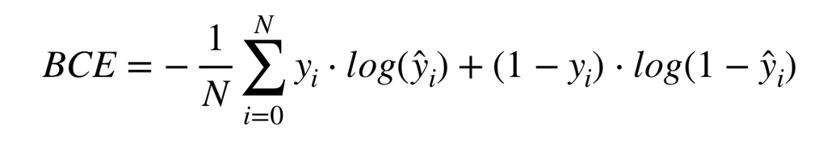

where y is the label and p(y) is the predicted probability of the point being 1 for all N points.

You can read more about loss functions here: https://machinelearningmastery.com/how-to-choose-loss-functions-when-training-deep-learning-neural-networks/

You can read about the loss functions available in Keras here: https://keras.io/losses/

#### Optimizers

Now we need to choose how we will train our model:

- Learn weights that minimize the specified loss function

We’ll use stochastic gradient descent (sgd).

You can read about Keras’s other optimizers here: https://keras.io/optimizers/

#### Metrics

We also will specify what metrics we want to track during training. A metric, in this context, is a function used to evaluate the performance of a model.

You can read about the metrics available in Keras here: https://keras.io/metrics/

We will track accuracy.

```r
model %>%
  compile(
    loss = 'binary_crossentropy',
    optimizer = 'sgd',
    metrics = c('accuracy')
    )
```

### Setup data

Keras automatically adds a bias term, so we need to drop that bias feature from X.

We also need to make sure that the data structure matches the specified model structure.

```r
train_x <- array(X[,-1], dim = c(4, 2))
train_y <- array(R, dim = c(4,1))
```

```r
#Evaluating model on the cross validation dataset
loss_and_metrics <- model %>% evaluate(train_x, train_y, batch_size = 4)
```

```r
loss_and_metrics
```

$loss [1] 0.4616291

$acc [1] 1

```r
xor_R <- as.matrix(tibble(r = c(0, 1, 1, 0)))
```

```r
# Initialize the model
xor_model <- keras_model_sequential()
xor_model %>%
  layer_dense(units=1, input_shape = 2) %>%
  layer_activation('sigmoid')
xor_model %>%
  compile(
    loss = 'binary_crossentropy',
    optimizer = 'sgd',
    metrics = c('accuracy')
    )
```

```r
xor_train_y <- array(xor_R, dim = c(4,1))
```

```r
xor_model %>% fit(train_x, xor_train_y, epochs = 500, batch_size = 4)
```

#### Adding another layer

```r
xor_model2 %>%
  layer_dense(units=2, input_shape = 2) %>%
  layer_activation('tahn') %>%
  layer_dense(units=1, input_shape = 2) %>%
  layer_activation('sigmoid')
```

```
Error in py_call_impl(callable, dots$args, dots$keywords) :
  ValueError: Unknown activation function:tahn
```

```r
xor_train_y <- array(xor_R, dim = c(4,1))
```

```r
xor_model2 %>% fit(train_x, xor_train_y, epochs = 5000, batch_size = 1)
```